# Оценка общего эффекта физической активности в отношении гликированного гемоглобина

Виктория Зайцева

2025-01-17

# Задача

Оценить общий эффект физической активности на уровень гликолизированного гемоглобина на основе данных NHANES 2013-2014.  
Согласно Википедии, гликированный гемоглобин отражает процент гемоглобина крови, необратимо соединенного с молекулами глюкозы, и является интегральным показателем гликемии за три месяца: чем выше уровень гликированного гемоглобина, тем выше была гликемия за последние три месяца и, соответственно, больше риск развития осложнений сахарного диабета.  
На основе литературных данных и предыдущих исследований с использованием данных NHANES, оптимальным методом оценки физической активности является использование шкалы MET (Metabolic Equivalent of Task).

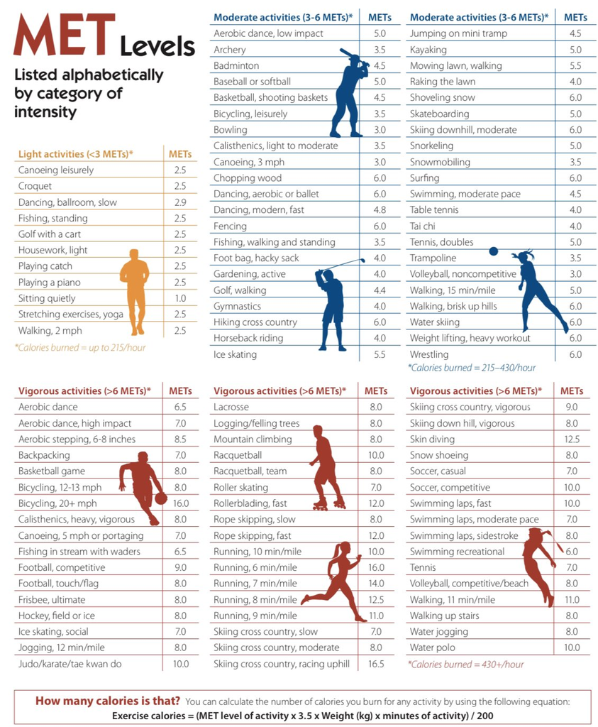

После расчета MET для каждой активности, финальной метрикой физической активности будет являться суммарное число MET-минут за неделю.

# Эксплораторный анализ

| **Characteristic** | **N = 916** |
| --- | --- |
| Gender |  |
| Male | 539 (59%) |
| Female | 377 (41%) |
| Race |  |
| Mexican | 101 (11%) |
| Hispanic | 75 (8.2%) |
| White | 463 (51%) |
| Black | 175 (19%) |
| Asian | 78 (8.5%) |
| Other | 24 (2.6%) |
| Education |  |
| <9th grade | 54 (5.9%) |
| 9-11th grade | 119 (13%) |
| High School | 203 (22%) |
| Student | 297 (32%) |
| Graduate | 243 (27%) |
| Income_Level |  |
| <4,999$ | 23 (2.5%) |
| 5k-9,999$ | 36 (3.9%) |
| 10k-14,999$ | 69 (7.5%) |
| 15k-19,999$ | 78 (8.5%) |
| 20k-24,999$ | 73 (8.0%) |
| 25k-34,999$ | 104 (11%) |
| 35k-44,999$ | 100 (11%) |
| 45k-54,999$ | 78 (8.5%) |
| 55k-64,999$ | 54 (5.9%) |
| 65k-74,999$ | 49 (5.3%) |
| 75k-99,999$ | 73 (8.0%) |
| 100k+ | 179 (20%) |
| Comorbidities | 374 (41%) |
| Smoking |  |
| Every Day | 133 (15%) |
| Sometimes | 31 (3.4%) |
| Never | 752 (82%) |
| GlyHemo |  |
| Mean (SD) | 5.80 (1.04) |
| Median (Q1-Q3) | 5.60 (5.30-5.90) |
| Min-Max | 4.20-13.90 |
| Total_MET |  |
| Mean (SD) | 2,349 (5,120) |
| Median (Q1-Q3) | 300 (-515-2,880) |
| Min-Max | -14,999-33,590 |

## Анализ категориальных переменных

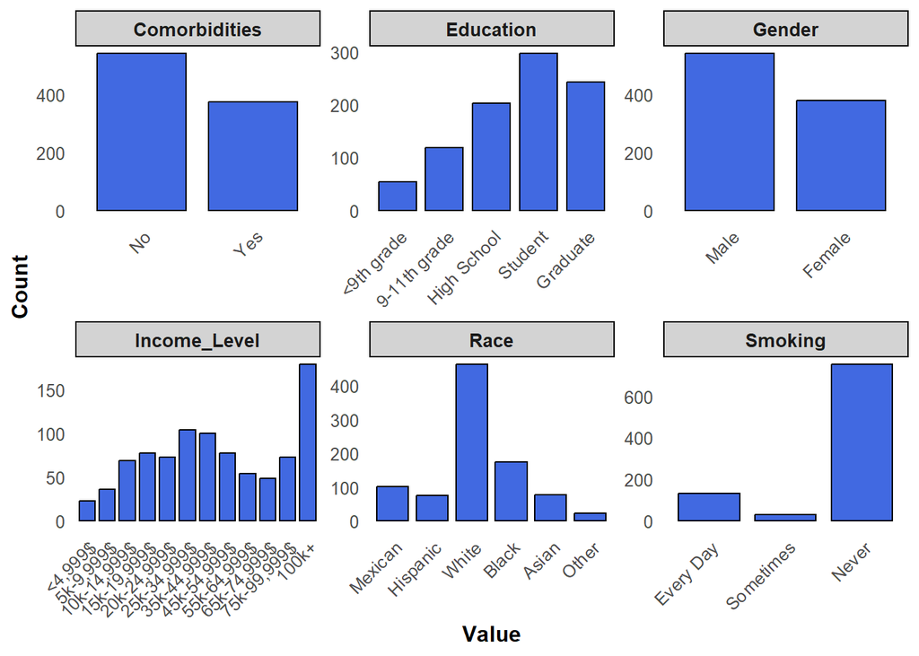

## Анализ количественных переменных

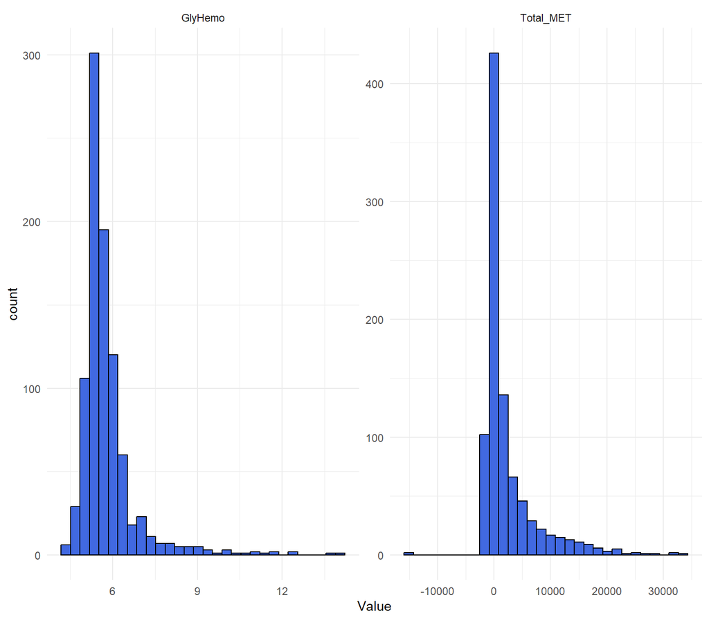

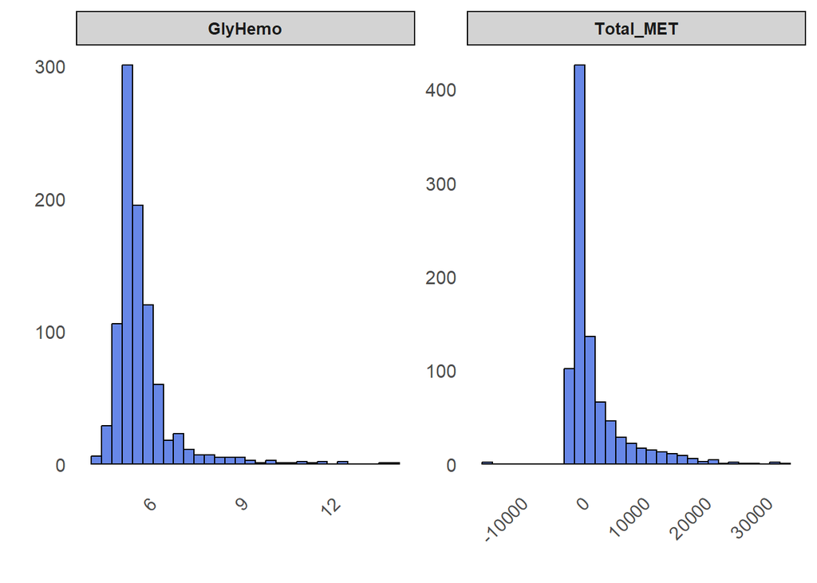

Физическая активность имеет ненормальное распределение, поэтому для дальнейшего анализа мы будем использовать логарифмированное значение физической активности.

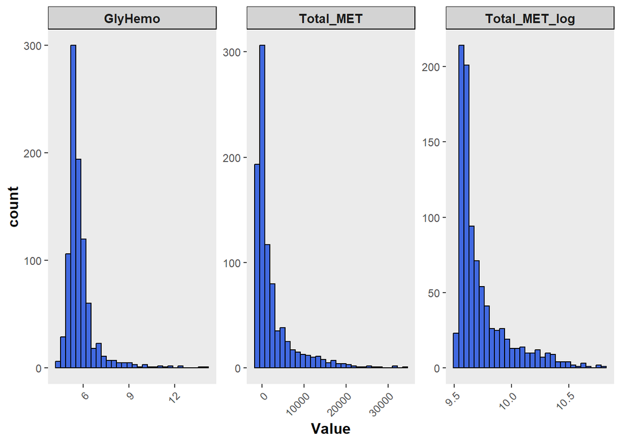

После логарифмирования распределение физической активности стало улучшилось. Логарифмирование также позволило уменьшить количество выбросов, потенциально улучшив качество модели.

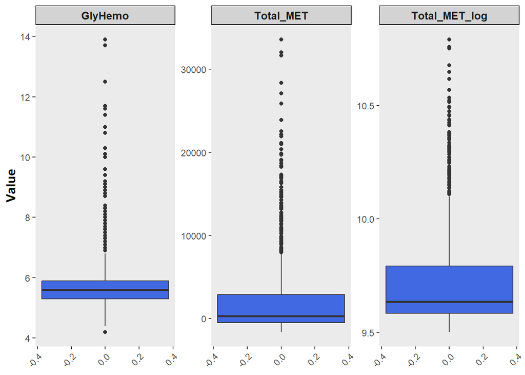

```
## # A tibble: 41 × 3
##    GlyHemo Total_MET Total_MET_log
##      <dbl>     <dbl>         <dbl>
##  1  1.35      3.30          3.05
##  2  3.47      1.34          1.56
##  3 -0.0996    4.64          3.83
##  4  5.40     -0.614        -0.719
##  5  3.09     -0.353        -0.336
##  6  4.15     -0.507        -0.558
##  7  3.66     -0.0448        0.0766
##  8 -0.293     3.29          3.04
##  9 -0.196     3.22          3.00
## 10  7.62      1.79          1.95
## # ℹ 31 more rows
```

Корреляционный анализ для предварительной оценки наличия ассоциации между физической активностью и уровнем гликолизированного гемоглобина не позволяет с уверенностью сказать, что есть какая-то ассоциация.

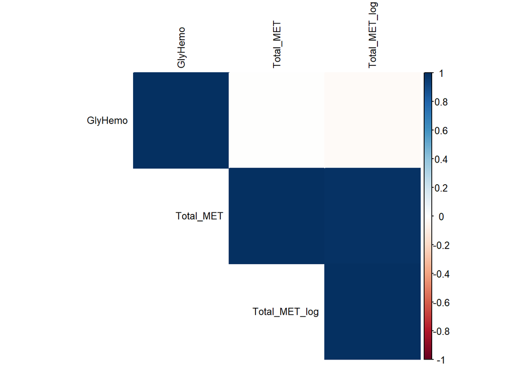

По результатам обзора литературы и общения с клиницистами мы визуализировали DAG модель, чтобы понять, какие факторы являются конфаундерами, медиаторами и коллайдерами в нашем исследовании.

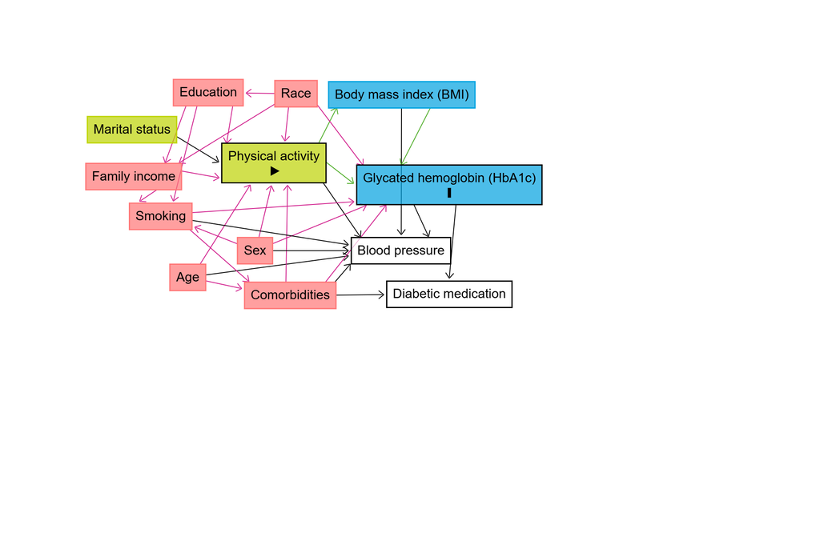

*Конфаундеры*: возраст, образование, доход, раса, пол, наличие заболеваний и курение.  
*Медиатор*: BMI  
*Коллайдеры*: наличие диабета, АД.